# Is Manual Transmission Better than Automatic Transmission? By How Much?

Jinghui Lim

1 November 2018

### Exploratory Analysis

I first load the data and examine the available variables and their means. I also convert variables that have several discrete values to factor variables (*transmission*, *cyl*, *vs*, *gear*, and *carb*).

```
## 'data.frame':    32 obs. of  11 variables:
##  $ mpg         : num  21 21 22.8 21.4 18.7 18.1 14.3 24.4 22.8 19.2 ...
##  $ cyl         : Factor w/ 3 levels "4","6","8": 2 2 1 2 3 2 3 1 1 2 ...
##  $ disp        : num  160 160 108 258 360 ...
##  $ hp          : num  110 110 93 110 175 105 245 62 95 123 ...
##  $ drat        : num  3.9 3.9 3.85 3.08 3.15 2.76 3.21 3.69 3.92 3.92 ...
##  $ wt          : num  2.62 2.88 2.32 3.21 3.44 ...
##  $ qsec        : num  16.5 17 18.6 19.4 17 ...
##  $ vs          : Factor w/ 2 levels "straight","v-shaped": 2 2 1 1 2 1 2 1 1 1 ...
##  $ transmission: Factor w/ 2 levels "automatic","manual": 2 2 2 1 1 1 1 1 1 1 ...
##  $ gear        : Factor w/ 3 levels "3","4","5": 2 2 2 1 1 1 1 2 2 2 ...
##  $ carb        : Factor w/ 6 levels "1","2","3","4",..: 4 4 1 1 2 1 4 2 2 4 ...
```

```
##       mpg           transmission
##  Min.   :10.40   automatic:19
##  1st Qu.:15.43   manual   :13
##  Median :19.20
##  Mean   :20.09
##  3rd Qu.:22.80
##  Max.   :33.90
```

As shown above, the variable *mpg* is the outcome variable. It is a continuous variable with a mean of 20.09 mpg. The explanatory variable *manual* is a binary/factor variable that takes values 0 for automatic transmission and 1 for manual tranmission, and 40.6% (13/32) of the models in the data have manual transmission. Next, I explore the relationship between transmission type and fuel economy.

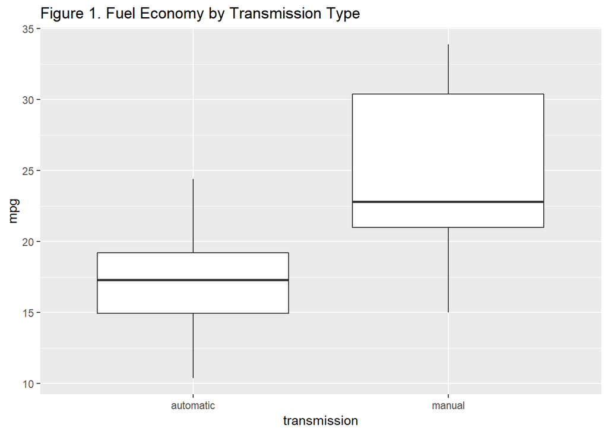

As shown in Figure 1, automatic transmission cars have a median fuel economy of 17.3 mpg, while manual cars have a median of 22.8 mpg.

```
## $automatic
##    Min. 1st Qu.  Median    Mean 3rd Qu.    Max.
##   10.40   14.95   17.30   17.15   19.20   24.40
##
## $manual
##    Min. 1st Qu.  Median    Mean 3rd Qu.    Max.
##   15.00   21.00   22.80   24.39   30.40   33.90
```

As shown in the table above, automatic transmission cars have a mean 17.15 mpg, while maual cars have a mean of 24.39. Based on the plot in Figure 1 and the table above, there seems to be a difference in fuel economy for different types of transmission, and it is worth more in-depth analysis.

### Model Selection

As the outcome variable *mpg* is continuous a linear model is appropriate. I first look at the most parsimonious model, regression *mpg* on only *transmission* and an intercept.

```
##                     Estimate Std. Error   t value     Pr(>|t|)
## (Intercept)        17.147368   1.124603 15.247492 1.133983e-15
## transmissionmanual  7.244939   1.764422  4.106127 2.850207e-04
```

As shown above, manual transmission improves on fuel economy over automatic transmission by 7.2 mpg. The coefficient is statistically significant at the 1% level. The intercept term is, unsurprisingly, the mean fuel economy of automatic cars, 17.1.

Next, I perform nested model testing to choose the correct variables and models.

```
## Analysis of Variance Table
##
## Model 1: mpg ~ transmission
## Model 2: mpg ~ transmission + cyl + wt
## Model 3: mpg ~ transmission + cyl + wt + disp + hp
## Model 4: mpg ~ cyl + disp + hp + drat + wt + qsec + vs + transmission +
##     gear + carb
##   Res.Df    RSS Df Sum of Sq       F    Pr(>F)
## 1     30 720.90
## 2     27 182.97  3    537.93 22.3387 8.689e-06 ***
## 3     25 150.41  2     32.56  2.0282    0.1661
## 4     15 120.40 10     30.01  0.3738    0.9397
## ---
## Signif. codes:  0 '***' 0.001 '**' 0.01 '*' 0.05 '.' 0.1 ' ' 1
```

As shown above, model 2, with *transmission*, *cylinders*, and *weight*, is the best model. The p values for models 3 and 4 are well above 5%, so the new variables are not necessary in the model. Thus, the best model is:

```
##                      Estimate Std. Error    t value     Pr(>|t|)
## (Intercept)        33.7535920  2.8134831 11.9970836 2.495549e-12
## transmissionmanual  0.1501031  1.3002231  0.1154441 9.089474e-01
## cyl6               -4.2573185  1.4112394 -3.0167231 5.514697e-03
## cyl8               -6.0791189  1.6837131 -3.6105432 1.227964e-03
## wt                 -3.1495978  0.9080495 -3.4685309 1.770987e-03
```

As shown from the table, the coefficient for manual transmission is positive; using manual (instead of automatic) transmission increases fuel economy by 0.15 mpg. However, it is not significant (*p* = 0.90). So, based on the data, manual transmission cars do not have a statistically significant difference in fuel economy than automatic transmission cars.

It is interesting to note that the most parsimonious model (with only *transmission*) showed a large (7.2 mpg) and statistically significant (*p* < 0.01) difference in fuel economy. However, it seems that the weight and number of cylinders of the car accounted for that difference, while transmission was merely correlated with these two important variables.

### Residuals and Diagnostics

Next, in order to confirm that the analysis has not missed anything, I perform some diagnostics on the residuals.

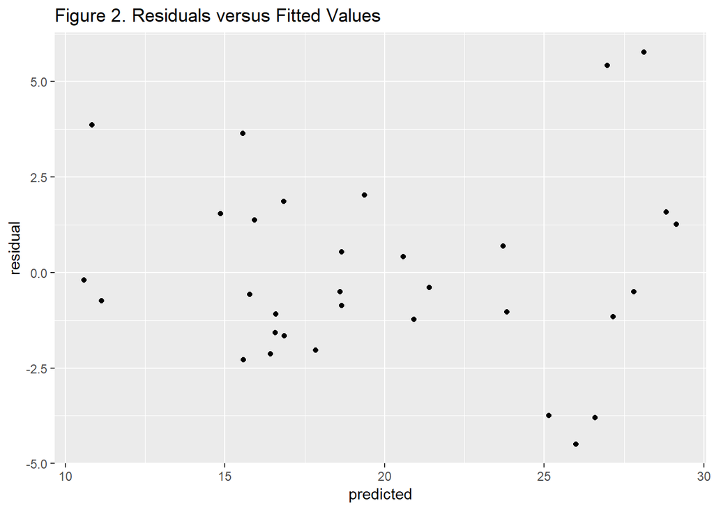

As shown in Figure 2, there is no easily discernable pattern between the residuals and the fitted values. The code appendix contains the all four diagnostic plots.

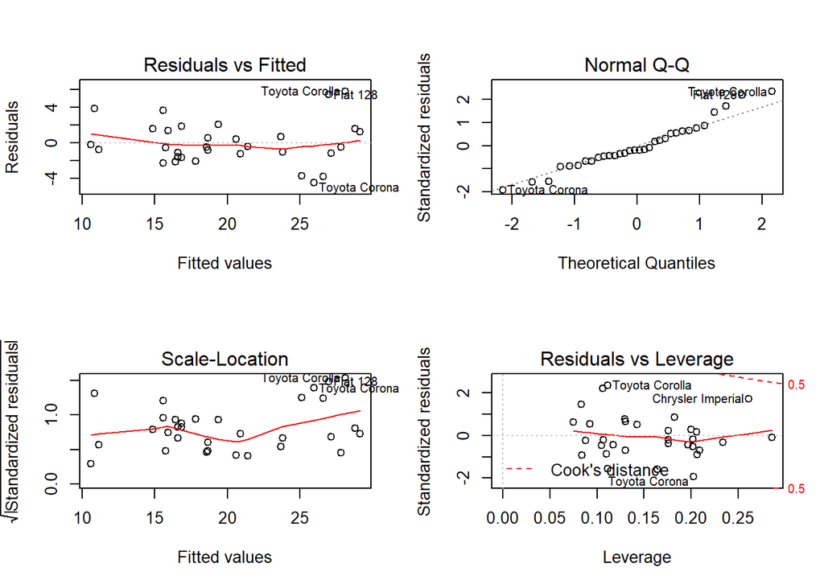

# Code and Output Appendix

In this appendix, I present the code and output.

```r
knitr::opts_chunk$set(echo = FALSE)     # knitr code options (code in appendix)
rm(list = ls())
library(ggplot2)
library(dplyr)
data(mtcars)
# making the outcome variable more self-explanatory
mtcars$am <- ifelse(mtcars$am == 1, "manual", "automatic")
mtcars <- rename(mtcars, transmission = am)
mtcars$transmission <- as.factor(mtcars$transmission)
mtcars$cyl <- as.factor(mtcars$cyl)
mtcars$vs <- ifelse(mtcars$vs == 0, "v-shaped", "straight")
mtcars$vs <- as.factor(mtcars$vs)
mtcars$gear <- as.factor(mtcars$gear)
mtcars$carb <- as.factor(mtcars$carb)
str(mtcars)
```

```
## 'data.frame':    32 obs. of  11 variables:
##  $ mpg         : num  21 21 22.8 21.4 18.7 18.1 14.3 24.4 22.8 19.2 ...
##  $ cyl         : Factor w/ 3 levels "4","6","8": 2 2 1 2 3 2 3 1 1 2 ...
##  $ disp        : num  160 160 108 258 360 ...
##  $ hp          : num  110 110 93 110 175 105 245 62 95 123 ...
##  $ drat        : num  3.9 3.9 3.85 3.08 3.15 2.76 3.21 3.69 3.92 3.92 ...
##  $ wt          : num  2.62 2.88 2.32 3.21 3.44 ...
##  $ qsec        : num  16.5 17 18.6 19.4 17 ...
##  $ vs          : Factor w/ 2 levels "straight","v-shaped": 2 2 1 1 2 1 2 1 1 1 ...
##  $ transmission: Factor w/ 2 levels "automatic","manual": 2 2 2 1 1 1 1 1 1 1 ...
##  $ gear        : Factor w/ 3 levels "3","4","5": 2 2 2 1 1 1 1 2 2 2 ...
##  $ carb        : Factor w/ 6 levels "1","2","3","4",..: 4 4 1 1 2 1 4 2 2 4 ...
```

```r
# sapply(mtcars, mean)
summary(select(mtcars, mpg, transmission))
```

```
##       mpg           transmission
##  Min.   :10.40   automatic:19
##  1st Qu.:15.43   manual   :13
##  Median :19.20
##  Mean   :20.09
##  3rd Qu.:22.80
##  Max.   :33.90
```

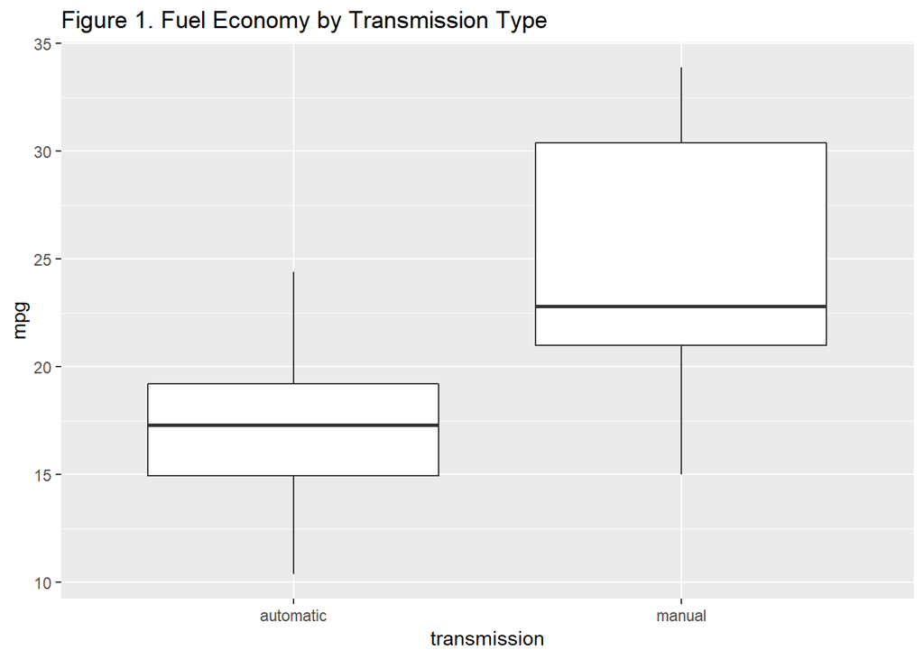

```r
g <- ggplot(mtcars, aes(x = transmission, y = mpg)) + geom_boxplot() +
    labs(title = "Figure 1. Fuel Economy by Transmission Type")
g
```

```r
tapply(mtcars$mpg, mtcars$transmission, summary)
```

```
## $automatic
##    Min. 1st Qu.  Median    Mean 3rd Qu.    Max.
##   10.40   14.95   17.30   17.15   19.20   24.40
##
## $manual
##    Min. 1st Qu.  Median    Mean 3rd Qu.    Max.
##   15.00   21.00   22.80   24.39   30.40   33.90
```

```r
fit1 <- lm(mpg ~ transmission, mtcars)
summary(fit1)$coef
```

```
##                     Estimate Std. Error   t value     Pr(>|t|)
## (Intercept)        17.147368   1.124603 15.247492 1.133983e-15
## transmissionmanual  7.244939   1.764422  4.106127 2.850207e-04
```

```r
fit3 <- lm(mpg ~ transmission + cyl + wt, mtcars)
fit5 <- lm(mpg ~ transmission + cyl + wt + disp + hp, mtcars)
fitAll <- lm(mpg ~ ., mtcars)
anova(fit1, fit3, fit5, fitAll)
```

```
## Analysis of Variance Table
##
## Model 1: mpg ~ transmission
## Model 2: mpg ~ transmission + cyl + wt
## Model 3: mpg ~ transmission + cyl + wt + disp + hp
## Model 4: mpg ~ cyl + disp + hp + drat + wt + qsec + vs + transmission +
##     gear + carb
##   Res.Df    RSS Df Sum of Sq       F    Pr(>F)
## 1     30 720.90
## 2     27 182.97  3    537.93 22.3387 8.689e-06 ***
## 3     25 150.41  2     32.56  2.0282    0.1661
## 4     15 120.40 10     30.01  0.3738    0.9397
## ---
## Signif. codes:  0 '***' 0.001 '**' 0.01 '*' 0.05 '.' 0.1 ' ' 1
```

```r
fit <- fit3
rm(fit1, fit3, fit5, fitAll)    # removing the other models to reduce confusion
summary(fit)$coef
```

```
##                      Estimate Std. Error    t value     Pr(>|t|)
## (Intercept)        33.7535920  2.8134831 11.9970836 2.495549e-12
## transmissionmanual  0.1501031  1.3002231  0.1154441 9.089474e-01
## cyl6               -4.2573185  1.4112394 -3.0167231 5.514697e-03
## cyl8               -6.0791189  1.6837131 -3.6105432 1.227964e-03
## wt                 -3.1495978  0.9080495 -3.4685309 1.770987e-03
```

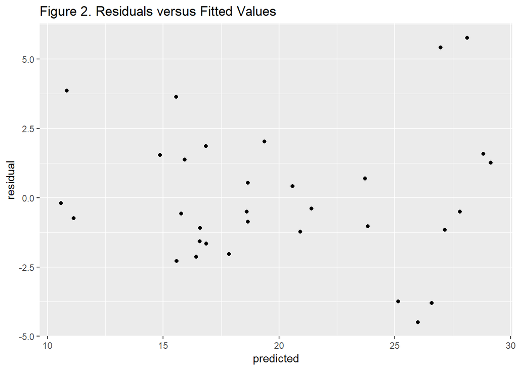

```r
mtcars$predicted <- predict(fit)
mtcars$residual <- fit$residuals
#qplot(predict(fit), fit$residuals)
g <- ggplot(mtcars, aes(x = predicted, y = residual)) + geom_point() +
    labs(title = "Figure 2. Residuals versus Fitted Values")
g
```

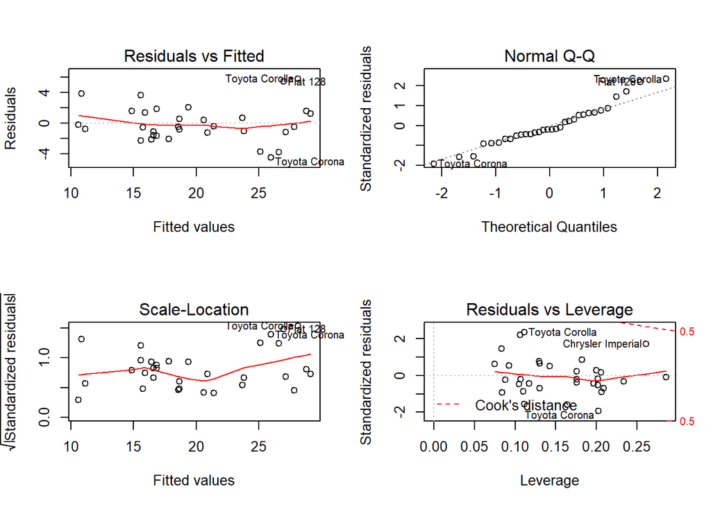

```r
par(mfrow = c(2, 2))
plot(fit)
```

```r
#round(dfbetas(fit)[, 2], 3)
#round(hatvalues(fit), 3)
```